# Probability Assignment

Thomas Courtney

9/6/2020

Question 1

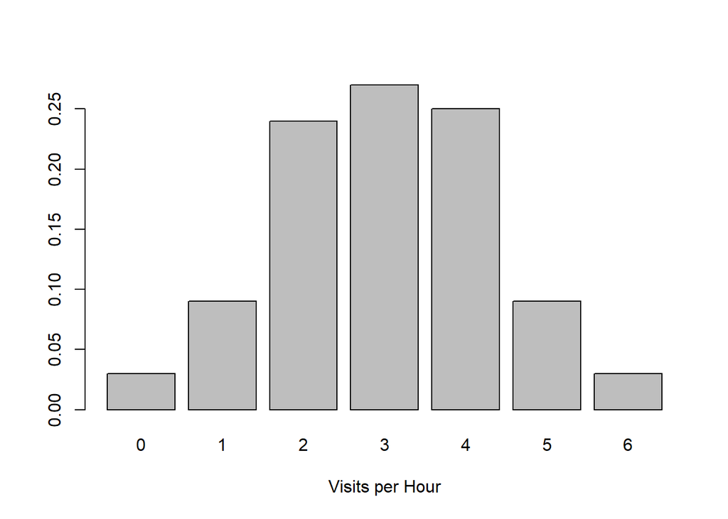

```r
barplot(c(.03,.09,.24, .27, .25, .09, .03), names.arg=c(0,1,2,3,4,5,6), xlab="Visits per Hour")
```

```r
p<-c(.03,.09,.24, .27, .25, .09, .03)
```

For a given hour, what is the probability that the number of visits will be between 4 and 6?

```r
(.25+.09+.03)
```

```
## [1] 0.37
```

37% likelihood that the number of visits will be between 4 and 6

Compute the mean, the variance, and the standard deviation of the number of visits per hour.

```r
names.arg=c(0,1,2,3,4,5,6)
p<-c(.03,.09,.24, .27, .25, .09, .03)

mean_expected_value<-sum(c(p*names.arg))
mean_expected_value
```

```
## [1] 3.01
```

```r
variance<-sum((p*names.arg^2))-(mean_expected_value)^2
variance
```

```
## [1] 1.7499
```

```r
sqrt(variance)
```

```
## [1] 1.322838
```

Expected Value is 3.01. The variance is 1.75. Standard deviation is 1.323

Question 2

Your client estimates that 68% of all visitors to the site are current college students. The remaining proportion have not attended or have already graduated. Suppose the site had 11 visitors in the last two hours.

Let X be the number of visitors (among the 11) who are college students. What assumptions should be satisfied for X to obey a binomial distribution B(n,p)?

The probability is the same, no matter which trial it is, since the trials are independent of one another. there are only two options, failure or success

Modeling X as a binomially distributed random variable, what is n and what is p in this case?

What is the probability that exactly 7 of the 11 visitors are college students?

```r
dbinom(7, size = 11, prob = 0.68)
```

```
## [1] 0.2326356
```

You have a .2326 probability of exactly 7 of the individuals being college students

What is the expected number of visitors (of the 11) who are college students? What is the standard deviation of the number of visitors who are college students?

```r
n = 11
p = 0.68

mean(n*p)
```

```
## [1] 7.48
```

```r
q= .32
sqrt(n*p*q)
```

```
## [1] 1.547126
```

The expected number of students is 7.48. The standard deviation is 1.547

Question 3

A website, hugeretail.com, features a huge variety of products for upscale consumers. These consumers are segmented into “mobile” and “desktop” consumers, as a function of how they complete the majority of their purchases, either via phone or some other device such as a laptop. 38% of the site’s consumer base are mobile consumers. The Consumer Fraud Division of the Department of Justice has begun a preliminary investigation into the online practices of hugeretail.com after an article exposed complaints of padded charges. Their first task is to choose a random sample of 20 customers for interviews and data collection regarding their transactions with hugeretail.com

What is the probability that 8 of the 20 randomly chosen consumers will be mobile consumers?

```r
dbinom(8, size = 20, prob = 0.38)
```

```
## [1] 0.1766998
```

the probability that 8 of 20 randomly chosen customers is 0.1767

What is the probability that between 12 and 14 of the 20 randomly chosen consumers will be desktop consumers?

```r
dbinom(12, size = 20, prob = 0.62)+
  dbinom(13, size = 20, prob = 0.62)+
  dbinom(14, size = 20, prob = 0.62)
```

```
## [1] 0.4988486
```

There is a 0.4988 likelihood that 12-14 of the 20 randomly chosen customers will be desktop users

What is the probability that 3 or fewer of the randomly chosen consumers will be desktop consumers?

```r
pbinom(3, size = 20, prob = 0.62)
```

```
## [1] 2.164264e-05
```

Question 4

```r
#You choose option A
(.6*1000000)+(.4*32000)
```

```
## [1] 612800
```

```r
#You choose option B
(.4*1000000)+(.6*32000)
```

```
## [1] 419200
```

```r
#You phone a friend
x=(.6*.8)+(.4*.8)
(x*1000000)+((1-x)*32000)
```

```
## [1] 806400
```

Question 5

With much acclaim, you have written a machine learning-based classifier which diagnoses a particular disease state. Given a person who has the disease, the probability that the classifier will fail to reveal the disease is 0.06. Given a person who does not have the disease, the classifier will correctly identify that the person does not have the disease with probability 0.91.

If someone has the disease, what is the probability that the classifier will identify that person as having the disease?

Suppose three unrelated individuals who do not have the disease are classified by your algorithm. What is the probability that at least one of the three individuals will be identified by your classifier as having the disease?

```r
dbinom(1, size = 3, prob = 0.09)
```

```
## [1] 0.223587
```

22% likelihood that one of the three people without the disease will be classified as having the disease

In a particular area of a particular country, 17% of the population suffers from this disease. If a random person from this area is tested and the results indicate that the person has the disease, what is the chance that the person actually has the disease?

```r
(.94*.17) + (.09*.83)
```

```
## [1] 0.2345
```

Question 6

Let’s look at overbooking. JetPurple Airlines’ first-class cabins have 10 seats per plane. JetPurple’s overbooking policy is to sell up to 11 first class tickets, since cancellations and no-shows are always possible (and quite likely). For a given flight on JetPurple, there were 11 first class tickets sold. Suppose that each of the 11 persons who purchased tickets has a 20% chance of not showing up for the flight, and that the events that different persons show up for the flight are independent (e.g. the passengers are not traveling as part of a classy high school sports team).

What is the probability that at most 5 of the 11 persons who purchased first class tickets show up for the flight?

```r
pbinom(5, size = 11, prob = 1-0.20)
```

```
## [1] 0.01165421
```

There is a very small chance that five or less show up, at 1.165% chance

What is the probability that exactly 10 of the persons who purchased first class tickets show up for the flight?

```r
dbinom(10, size = 11, prob = 1-0.20)
```

```
## [1] 0.2362232
```

There is a 23.62% chance that exactly 10 people show up

Suppose that there are 10 seats in first class available and that the cost of each first-class ticket is $1,200. (This contributes entirely to profit since the variable cost associated with a passenger on a flight is close to zero.) Suppose further that any overbooked seat costs the airline $3,000, which is the cost of the free ticket plus some cost in damaged customer relations. (First class passengers do not expect to be bumped!) Thus, if 10 of the first-class passengers show up for the flight, the airline’s profit is $12,000. If 11 first class passengers show up, the profit is $9,000. What is the expected profit from first class passengers for this flight?

```r
exp_value=(11*.80)

all_eleven<-dbinom(11, size = 11, prob = 1-0.20)

exp_prof=(1200*8.8)-(3000*all_eleven)
exp_prof
```

```
## [1] 10302.3
```

The expected profit is $10,302 on all flights

Suppose that only 10 first class tickets were sold. What would be the expected profit from first class passengers for this flight?

```r
dbinom(10,size=10,prob = 1-.20)
```

```
## [1] 0.1073742
```

There is a small likelihood that 10 out of 10 passengers show up. there is a 10.74% chance that all ten passengers show up

(Think) People often travel in groups of two or more. Does this affect the independence assumption about passenger behavior? Why or why not?

Yes, because we really are not looking at 10 individuals, Instead, I would do 5 groups of two. This changes our probabilities tremendously